# Introduction to automated text analysis

Pablo Barbera

March 30, 2016

#### Dictionary methods

A different type of keyword analysis consists on the application of dictionary methods, or lexicon-based approaches to the measurement of tone or the prediction of diferent categories related to the content of the text.

The most common application is sentiment analysis: using a dictionary of positive and negative words, we compute a sentiment score for each individual document.

Let’s apply this technique in the context of our previous example.

```r
tweets <- read.csv("../datasets/icourts-tweets.csv", stringsAsFactors=F)
head(tweets)
```

```
##         id_str user.id_str                     created_at
## 1 6.836631e+17  3981918028 Sun Jan 03 14:56:00 +0000 2016
## 2 6.995180e+17  1362712638 Tue Feb 16 08:57:41 +0000 2016
## 3 6.846698e+17  2894493687 Wed Jan 06 09:36:09 +0000 2016
## 4 6.957115e+17    18023043 Fri Feb 05 20:51:51 +0000 2016
## 5 6.897207e+17  2428628620 Wed Jan 20 08:06:43 +0000 2016
## 6 6.901067e+17   202627333 Thu Jan 21 09:40:42 +0000 2016
##                                                                                                                                               text
## 1     RT @PSogeco: The WORLD QUICKLY FORGOTTEN Life conditions in #GAZA As in all probability had expected the ISRAELI government https://t.co/S7…
## 2 RT @IntlCrimCourt: #ICC President: "HR Courts &amp; International criminal courts are complementary in global #justice system" https://t.co/v7E…
## 3     RT @SchutzfaktorM: We thank @rights_info for their important work for the #ECHR in the UK and wish you good luck for 2016! #humanrights htt…
## 4         The atmophere of a school class@ivoirejustice report #ICC Gbagbo/Blé Goudé trial laughing defendents (in french) https://t.co/Kd33bYa2ET
## 5                                             #SouthAfrica - @StatsSA : #CPI inflation for December 2015 was 5 2% #StatsSA https://t.co/LcOBLIszVl
## 6               RT @oryembley: #ICC statements by the #OTP: "The LRA viewed the civilian inhabitants of northern Uganda as their enemies." #Ongwen
##   lang retweet_count
## 1   en             2
## 2   en            22
## 3   en             1
## 4   ht             0
## 5   en             0
## 6   en             1
```

```r
# loading lexicon of positive and negative words (from Neal Caren)
lexicon <- read.csv("../datasets/lexicon.csv", stringsAsFactors=F)
pos.words <- lexicon$word[lexicon$polarity=="positive"]
neg.words <- lexicon$word[lexicon$polarity=="negative"]
# a look at a random sample of positive and negative words
sample(pos.words, 10)
```

```
##  [1] "acknowledgement" "impeccable"      "prudently"
##  [4] "lucky"           "pinnacle"        "praise"
##  [7] "lofty"           "covenant"        "resilient"
## [10] "indulgent"
```

```r
sample(neg.words, 10)
```

```
##  [1] "foolishness"   "superficially" "flabbergasted" "scorchingly"
##  [5] "wretchedly"    "polarisation"  "invader"       "weakness"
##  [9] "defect"        "lousy"
```

Before we apply the sentiment analysis, we will need to go through several “preprocessing” steps before it can be passed to a statistical model. We’ll use the `quanteda` package quanteda here.

The basic unit of work for the `quanteda` package is called a `corpus`, which represents a collection of text documents with some associated metadata. Documents are the subunits of a corpus. We can then convert a corpus into a document-feature matrix using the `dfm` function.

```r
#install.packages("quanteda")
library(quanteda)
twcorpus <- corpus(tweets$text)
twdfm <- dfm(twcorpus, ngrams=c(1,3))
```

```
## Creating a dfm from a corpus ...
##    ... lowercasing
##    ... tokenizing
##    ... indexing documents: 5,000 documents
##    ... indexing features: 78,157 feature types
##    ... created a 5000 x 78157 sparse dfm
##    ... complete.
## Elapsed time: 1.108 seconds.
```

And to take a look at what the data looks like, we can generate a wordcloud

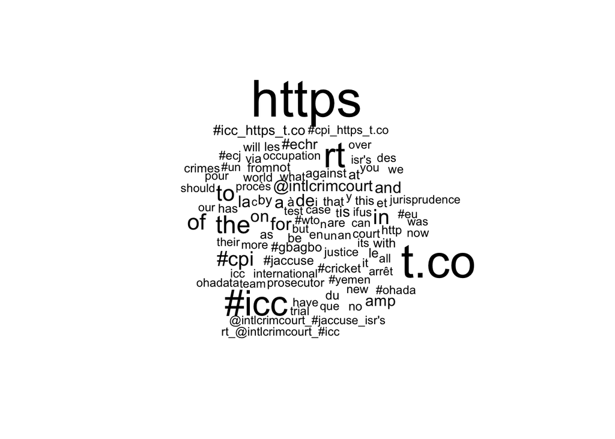

```r
plot(twdfm, rot.per=0, scale=c(3.5, .75), max.words=100)
```

We often want to remove words and symbols which are not of interest to our data, such as `http` here. One class of words which is not relevant are called *stopwords*. These are words which are common connectors in a given language (e.g. “a”, “the”, “is”). Another is punctuation.

```r
twdfm <- dfm(twcorpus, ignoredFeatures=c(
  stopwords("english"), stopwords("spanish"), stopwords("french"),
  "t.co", "https", "rt", "amp", "http", "t.c", "can"), ngrams=c(1,3))
```

```
## Creating a dfm from a corpus ...
##    ... lowercasing
##    ... tokenizing
##    ... indexing documents: 5,000 documents
##    ... indexing features: 78,157 feature types
##    ... removed 41,451 features, from 630 supplied (glob) feature types
##    ... created a 5000 x 36706 sparse dfm
##    ... complete.
## Elapsed time: 4.562 seconds.
```

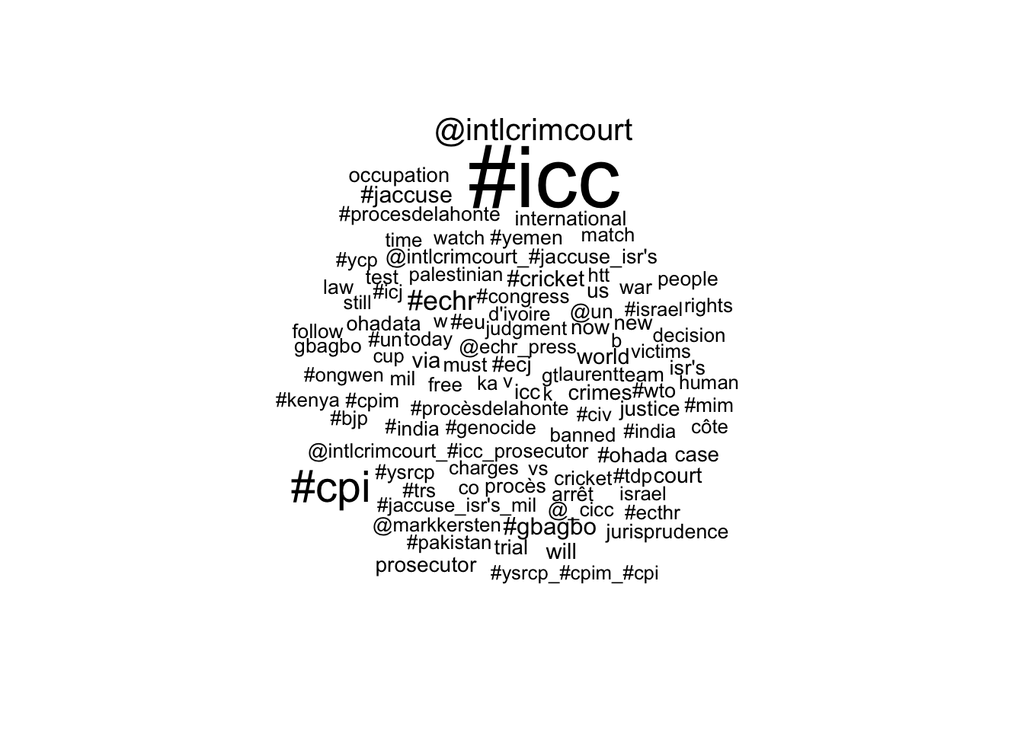

```r
plot(twdfm, rot.per=0, scale=c(3.5, .75), max.words=100)
```

We can also look at the most common tokens in this dataset with the `topfeatures` function:

```r
topfeatures(twdfm, 25)
```

```
##           #icc           #cpi @intlcrimcourt          #echr        #gbagbo
##           2504            944            470            342            214
##       #jaccuse            via       #cricket           will          world
##            185            157            157            154            148
##          court         crimes             us           #ecj     prosecutor
##            134            130            121            116            116
##            icc            now        justice            new           case
##            115            115            114            109            106
##          trial         #ohada     occupation            #eu        ohadata
##            102            102             98             96             91
```

Now we’re ready to run the sentiment analysis!

```r
# first we construct a dictionary object
mydict <- dictionary(list(negative = neg.words,
                          positive = pos.words))
# apply it to our corpus
sent <- dfm(twcorpus, dictionary = mydict)
```

```
## Creating a dfm from a corpus ...
##    ... lowercasing
##    ... tokenizing
##    ... indexing documents: 5,000 documents
##    ... indexing features: 20,125 feature types
##    ... applying a dictionary consisting of 2 keys
##    ... created a 5000 x 2 sparse dfm
##    ... complete.
## Elapsed time: 12.356 seconds.
```

```r
# and add it as a new variable
tweets$score <- as.numeric(sent[,2]) - as.numeric(sent[,1])
```

```r
# what is the average sentiment score?
mean(tweets$score)
```

```
## [1] 0.0438
```

```r
# what is the most positive and most negative tweet?
tweets[which.max(tweets$score),]
```

```
##            id_str user.id_str                     created_at
## 1739 6.692991e+17  2219627232 Tue Nov 24 23:38:32 +0000 2015
##                                                                                                                                                      text
## 1739 RT @ICJConsortium: Expert&amp;practical capacity building support from int'l legal community can help improve #ICC effectiveness&amp;efficiency htt…
##      lang retweet_count score
## 1739   en             1     6
```

```r
tweets[which.min(tweets$score),]
```

```
##            id_str user.id_str                     created_at
## 2435 6.742845e+17  2783538092 Tue Dec 08 17:48:39 +0000 2015
##                                                                                                                                              text
## 2435 RT @Mambear04: Despicable @UN Vile Israeli racist slaughter of Youth In #Palestine continues! No more #ICC impunity @FedericaMog!  https://…
##      lang retweet_count score
## 2435   en             2    -5
```

```r
# what is the proportion of positive, neutral, and negative tweets?
tweets$sentiment <- "neutral"
tweets$sentiment[tweets$score<0] <- "negative"
tweets$sentiment[tweets$score>0] <- "positive"
table(tweets$sentiment)
```

```
##
## negative  neutral positive
##      933     2996     1071
```

We can also disaggregate by groups of tweets, for example according to the hashtag they mention.

```r
hts <- c("ICC", "ECHR", "ECJ")

for (h in hts){
  message(h, " -- average sentiment: ",
      round(mean(tweets$score[grep(h, tweets$text, ignore.case=TRUE)]), 4)
    )
}
```

```
## ICC -- average sentiment: 0.0019
```

```
## ECHR -- average sentiment: 0.1312
```

```
## ECJ -- average sentiment: 0.0833
```